## Executive Summary

Human Activity Recognition (HAR) is a research area to identify different activities based on the data recorded by various sensors. There are many potential applications for HAR, like: elderly monitoring, life log systems for monitoring energy expenditure and for supporting weight-loss programs, and digital assistants for weight lifting exercises.

This report is to build the prediction model that can predict the type of activity performed by a person, based on the data collected from sensors. Research data has been collected from here - http://groupware.les.inf.puc-rio.br/har

The purpose of this investivgation is to identify “how (well)” an activity was performed by a person. The measurements are taken by on-body sensors, with five different set of activities. Participants were asked to perform one set of 10 repetitions of the Unilateral Dumbbell Biceps Curl in five different fashions: exactly according to the specification (Class A), throwing the elbows to the front (Class B), lifting the dumbbell only halfway (Class C), lowering the dumbbell only halfway (Class D) and throwing the hips to the front (Class E). Class A corresponds to the specified execution of the exercise, while the other 4 classes correspond to common mistakes.

## Data Analysis

The training data for this project are available here:

https://d396qusza40orc.cloudfront.net/predmachlearn/pml-training.csv

The test data are available here:

https://d396qusza40orc.cloudfront.net/predmachlearn/pml-testing.csv

The data for this project come from this source: http://groupware.les.inf.puc-rio.br/har.

Data can be downloaded from the links above and placed in the working directory.

```r
set.seed(16183)

data<- read.csv("pml-training.csv", na.strings = c("NA", ""), stringsAsFactors = F)
```

We have cleaned the data by removing columns with NULL values - these are derived columns and have less significance towards the prediction.

Cleaned training data has been divide into two parts - training set and testing set. We will use training set to train the prediction algorithm and testing set to find the accuracy of the model.

```r
completeColumns <- apply(!is.na(data), 2, all)

HAR <- data[, completeColumns]
HAR <- HAR[, -c(1, 2, 3, 4, 5, 6, 7)]
HAR$classe <- as.factor(HAR$classe)

# print predictors on which model is build
print(names(HAR))
```

```
##  [1] "roll_belt"            "pitch_belt"           "yaw_belt"
##  [4] "total_accel_belt"     "gyros_belt_x"         "gyros_belt_y"
##  [7] "gyros_belt_z"         "accel_belt_x"         "accel_belt_y"
## [10] "accel_belt_z"         "magnet_belt_x"        "magnet_belt_y"
## [13] "magnet_belt_z"        "roll_arm"             "pitch_arm"
## [16] "yaw_arm"              "total_accel_arm"      "gyros_arm_x"
## [19] "gyros_arm_y"          "gyros_arm_z"          "accel_arm_x"
## [22] "accel_arm_y"          "accel_arm_z"          "magnet_arm_x"
## [25] "magnet_arm_y"         "magnet_arm_z"         "roll_dumbbell"
## [28] "pitch_dumbbell"       "yaw_dumbbell"         "total_accel_dumbbell"
## [31] "gyros_dumbbell_x"     "gyros_dumbbell_y"     "gyros_dumbbell_z"
## [34] "accel_dumbbell_x"     "accel_dumbbell_y"     "accel_dumbbell_z"
## [37] "magnet_dumbbell_x"    "magnet_dumbbell_y"    "magnet_dumbbell_z"
## [40] "roll_forearm"         "pitch_forearm"        "yaw_forearm"
## [43] "total_accel_forearm"  "gyros_forearm_x"      "gyros_forearm_y"
## [46] "gyros_forearm_z"      "accel_forearm_x"      "accel_forearm_y"
## [49] "accel_forearm_z"      "magnet_forearm_x"     "magnet_forearm_y"
## [52] "magnet_forearm_z"     "classe"
```

```r
# create training set and testing set
inTrain <- createDataPartition(HAR$classe, p = 0.7, list = F)
training <- HAR[inTrain, ]
testing <- HAR[-inTrain, ]

table(training$classe)
```

```
##
##    A    B    C    D    E
## 3906 2658 2396 2252 2525
```

```r
table(testing$classe)
```

```
##
##    A    B    C    D    E
## 1674 1139 1026  964 1082
```

Since the different class of activities are depending on the body movement, let’s have a look at the total acceleration across all sensors and see if there is actually a separation of activities based on the sensors acceleration.

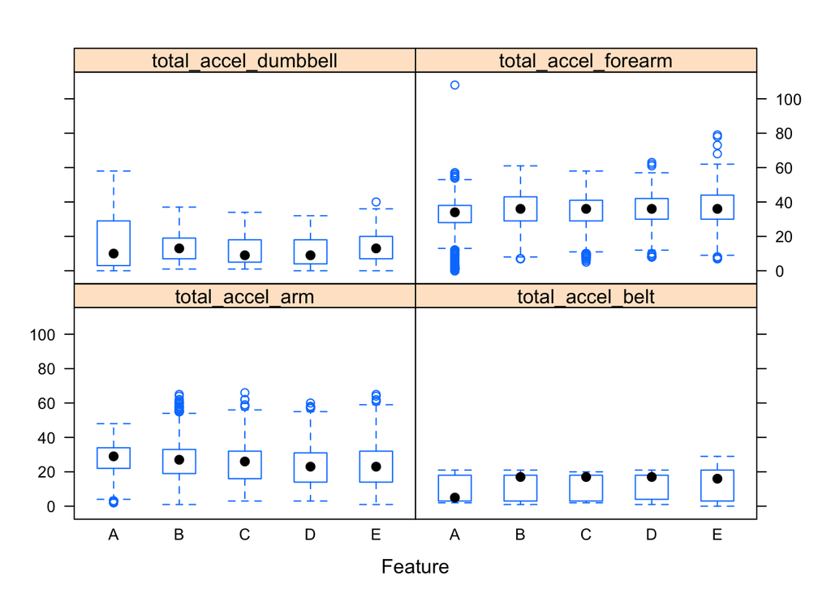

```r
 featurePlot(x = training[, c("total_accel_belt", "total_accel_arm", "total_accel_dumbbell",
        "total_accel_forearm")], y = training$classe, plot = "box", colours = training$classe)
```

## Building the Model

We will use Random Forest algorithm to build the prediction model. Random Forest model is tree based classification model, using multiple decision trees.

We will use caret package in R for this purpose.

```r
fitRF1 <- train(training$classe ~ ., data = training[, -53], method = "rf")

print(fitRF1)
```

```
## Random Forest
##
## 13737 samples
##    51 predictor
##     5 classes: 'A', 'B', 'C', 'D', 'E'
##
## No pre-processing
## Resampling: Bootstrapped (25 reps)
##
## Summary of sample sizes: 13737, 13737, 13737, 13737, 13737, 13737, ...
##
## Resampling results across tuning parameters:
##
##   mtry  Accuracy   Kappa      Accuracy SD  Kappa SD
##    2    0.9880679  0.9849042  0.002314346  0.002922938
##   27    0.9882797  0.9851724  0.001957722  0.002473492
##   52    0.9793223  0.9738390  0.004175416  0.005275967
##
## Accuracy was used to select the optimal model using  the largest value.
## The final value used for the model was mtry = 27.
```

```r
# predict activity on the testing data using above model
classPrediction1 <- predict(fitRF1, testing[, -53])
confusionMatrix(reference = testing$classe, data = classPrediction1)
```

```
## Confusion Matrix and Statistics
##
##           Reference
## Prediction    A    B    C    D    E
##          A 1672   10    0    0    0
##          B    1 1127    8    0    0
##          C    0    2 1016   15    1
##          D    0    0    2  949    1
##          E    1    0    0    0 1080
##
## Overall Statistics
##
##                Accuracy : 0.993
##                  95% CI : (0.9906, 0.995)
##     No Information Rate : 0.2845
##     P-Value [Acc > NIR] : < 2.2e-16
##
##                   Kappa : 0.9912
##  Mcnemar's Test P-Value : NA
##
## Statistics by Class:
##
##                      Class: A Class: B Class: C Class: D Class: E
## Sensitivity            0.9988   0.9895   0.9903   0.9844   0.9982
## Specificity            0.9976   0.9981   0.9963   0.9994   0.9998
## Pos Pred Value         0.9941   0.9921   0.9826   0.9968   0.9991
## Neg Pred Value         0.9995   0.9975   0.9979   0.9970   0.9996
## Prevalence             0.2845   0.1935   0.1743   0.1638   0.1839
## Detection Rate         0.2841   0.1915   0.1726   0.1613   0.1835
## Detection Prevalence   0.2858   0.1930   0.1757   0.1618   0.1837
## Balanced Accuracy      0.9982   0.9938   0.9933   0.9919   0.9990
```

### Model Tuning and Testing

Since the sensors are to detect the direction of the motion, it is likely that one sensor’s measurement (x,y,x directions) is correlated to other sensor’s measurement. We can find such correlated features by running the Principle Component Analysis on the data. We will extract the features which can explain up to 99% variability in the training set.

```r
 # check for variables which are highly correlated
preProc <- preProcess(training[,  -53], method = "pca", thresh = 0.99)

# training data and testing data should be passed through same PCA analysis
trainPCA <- predict(preProc, training[, -53])
testPCA <- predict(preProc, testing[, -53])

print (preProc)
```

```
##
## Call:
## preProcess.default(x = training[, -53], method = "pca", thresh = 0.99)
##
## Created from 13737 samples and 52 variables
## Pre-processing: principal component signal extraction, scaled, centered
##
## PCA needed 36 components to capture 99 percent of the variance
```

To avoid overfitting the model on the training set, we will perform cross validation on the model. For this purpose, we have selected 3 fold cross validation.

```r
fitControl <- trainControl(method = "cv", number = 3)
```

Now, we will build the model again by using identified principle components in the training set and apply 3 fold cross validation to generalize the model.

```r
fitRF2 <- train(training$classe ~ ., trControl = fitControl, data = trainPCA, method = "rf")

print(fitRF2)
```

[output not shown]

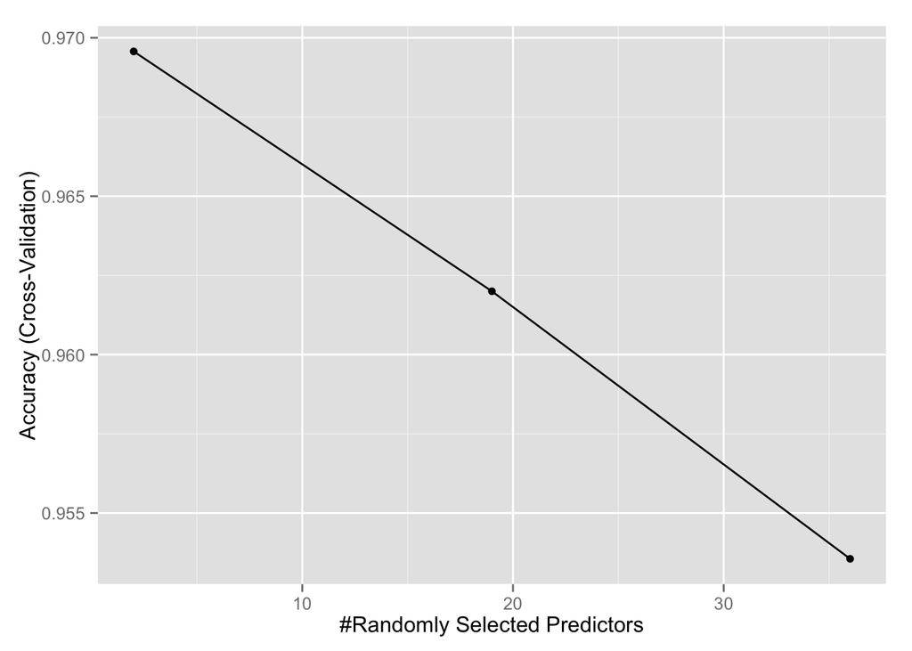

```r
ggplot(fitRF2)
```

### Model Accuracy

We will predict the activity class on the testing set to find the model accuracy.

```r
classPrediction2 <- predict(fitRF2, testPCA)

confusionMatrix(testing$classe, classPrediction2)
```

```
## Confusion Matrix and Statistics
##
##           Reference
## Prediction    A    B    C    D    E
##          A 1668    2    1    2    1
##          B   24 1111    3    0    1
##          C    1   19 1003    3    0
##          D    0    0   53  908    3
##          E    0    2   13    5 1062
##
## Overall Statistics
##
##                Accuracy : 0.9774
##                  95% CI : (0.9733, 0.981)
##     No Information Rate : 0.2877
##     P-Value [Acc > NIR] : < 2.2e-16
##
##                   Kappa : 0.9714
##  Mcnemar's Test P-Value : NA
##
## Statistics by Class:
##
##                      Class: A Class: B Class: C Class: D Class: E
## Sensitivity            0.9852   0.9797   0.9348   0.9891   0.9953
## Specificity            0.9986   0.9941   0.9952   0.9887   0.9958
## Pos Pred Value         0.9964   0.9754   0.9776   0.9419   0.9815
## Neg Pred Value         0.9941   0.9952   0.9856   0.9980   0.9990
## Prevalence             0.2877   0.1927   0.1823   0.1560   0.1813
## Detection Rate         0.2834   0.1888   0.1704   0.1543   0.1805
## Detection Prevalence   0.2845   0.1935   0.1743   0.1638   0.1839
## Balanced Accuracy      0.9919   0.9869   0.9650   0.9889   0.9956
```